# [TWD] Praca Domowa nr 4

Szymon Maksymiuk

7 listopada 2018

# Wprowadzenie

W związku z uroczystością Wszystkich Świętych, którą obchodziliśmy niemal tydzień temu, postanowiłem pochylić się nad tematem naszego bezpieczeństwa w trakcie tych dni na przestrzeni lat. Jak wiemy w czasie tych swiąt Policja co roku organizuje akcję “Znicz” polegającą na wzmożonych kontrolach na drogach. Dzięki danym zebranym na stronie http://statystyka.policja.pl/st/ruch-drogowy/dlugie-weekendy-i-swie/76569,Akcja-quotZniczquot.html możemy porównac jak na przestrzeni lat prezentowała się sytuacja na polskich drogach.

# Wersja z odcieniami szarości

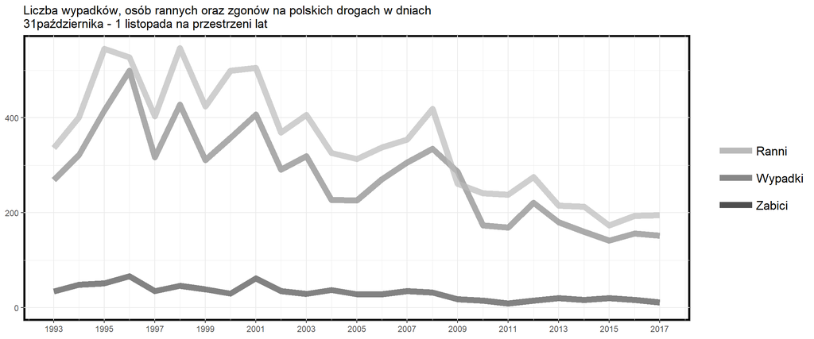

# Wersja z kolorami

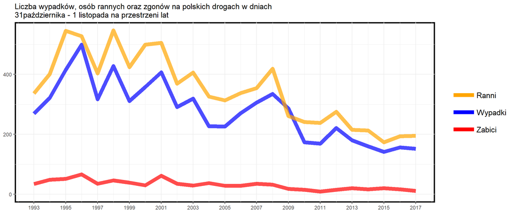

# Podsumowanie

Pierwszy wykres, subiektywnie mówiąc, nie jest miły dla oka. Fakt utrzymania go w odcieniach szarości sprawia, że wszystko nam się na nim zlewa, musimy wytężyć wzork aby rozróżnić poszczególne kategorie. Przedstawione dane szczególnie pokazują jak ważny jest rozróżnialny kolor. Wartości kategorii “Ranni” oraz “Wypadki” często są blisko siebie, zdarza się im nawet krzyżować przez co rozróżnienie linii jest jeszcze trudniejsze. Patrząc na drugi wykres naszą uwagę od razu przykuwają barwy. Według mnie oprócz tego, że w oczywisty sposób ułatwiają odczytanie danych z wykresu to dodają dużo walorów estetycznych dzięki czemu patrzenie na wykres w celu odczytania poszczególnych wartości nie jest już katorgą (w sensie estetycznym jak i zdrowotnym - oczy nie bolą od wytężania wzorku) a przyjemnością. Poświęcając zdanie samym danym, łatwo zauważyć pokrzepiający serca fakt, że ogólna liczba wypadków spada na przestrzeni lat. Jeżeli chodzi o samą liczbę wypadków jak i rannych to obniżyła się ona w porównaniu do początków akcji około dwukrotnie co według mnie jest sukcesem podnoszenia śwaidomości wśród polskich kierowców. Liczba osób, które tracą życie na drogach również ku uciesze nas wszystkich maleje.